# Computationally Efficient Predictions for Multi-Output Spatiotemporal Dynamical Systems

Research Comprehensive Exam

Joey Hotz

joey.hotz@mail.utoronto.ca

Department of Statistical Sciences, University of Toronto

November 11, 2026

## Outline

1. Background: Gaussian processes & Kalman filtering
2. The GPKF approach of Todescato et al. (2020)
3. Extension to multi-output responses
4. Simulation study
5. Discussion & future work

# Background

## Math

A latent Gaussian process with i.i.d. noise:

$$y_i = f(\mathbf{x}_i, t_i) + \varepsilon_i,
\qquad f \sim \mathcal{GP}\big(0, k(\cdot, \cdot)\big),
\qquad \varepsilon_i \overset{\scriptscriptstyle{\textrm{i.i.d.}}}{\sim}\mathcal{N}(0, \sigma^2).$$

Posterior mean and variance at a new input $\mathbf{x}_*$:

$$\begin{aligned}
\mathbb{E}_{}\!\left[f_* \mid \mathbf{y}\right] &= {\mathbf{k}_*}^{\scriptstyle{\mathsf{T}}} \left(\mathbf{K}+ \sigma^2 \mathbf{I}\right)^{-1} \mathbf{y}, \\
\operatorname{Var}_{}\!\left(f_* \mid \mathbf{y}\right) &= k_{**} - {\mathbf{k}_*}^{\scriptstyle{\mathsf{T}}} \left(\mathbf{K}+ \sigma^2 \mathbf{I}\right)^{-1} \mathbf{k}_*.
\end{aligned}$$

**Cost**

Naïve inference is $\mathcal{O}(n^3)$ in the number of observations $n$.

## Definitions, theorems & callouts

**Definition (State-space model)**

$\mathbf{z}_{k+1} = \mathbf{A}\mathbf{z}_k + \mathbf{w}_k$, $\quad y_k = \mathbf{C}\mathbf{z}_k + v_k$.

# Methods

## Two columns

**Left column**

**Right column**

```python
import numpy as np

def rbf(x, y, ell=1.0):
    return np.exp(-0.5 * (x - y)**2 / ell**2)
```

## Algorithm

**Algorithm 1:** Kalman filter (one step)

1. **Predict:** $\hat{\mathbf{z}}_{k \mid k-1} = \mathbf{A}\hat{\mathbf{z}}_{k-1}$, $\quad \mathbf{P}_{k \mid k-1} = \mathbf{A}\mathbf{P}_{k-1} {\mathbf{A}}^{\scriptstyle{\mathsf{T}}} + \mathbf{Q}$
2. **Gain:** $\mathbf{G}_k = \mathbf{P}_{k \mid k-1} {\mathbf{C}}^{\scriptstyle{\mathsf{T}}} \left(\mathbf{C}\mathbf{P}_{k \mid k-1} {\mathbf{C}}^{\scriptstyle{\mathsf{T}}} + \mathbf{R}\right)^{-1}$
3. **Update:** $\hat{\mathbf{z}}_k = \hat{\mathbf{z}}_{k \mid k-1} + \mathbf{G}_k \left(\mathbf{y}_k - \mathbf{C}\hat{\mathbf{z}}_{k \mid k-1}\right)$

# Results

## A single figure

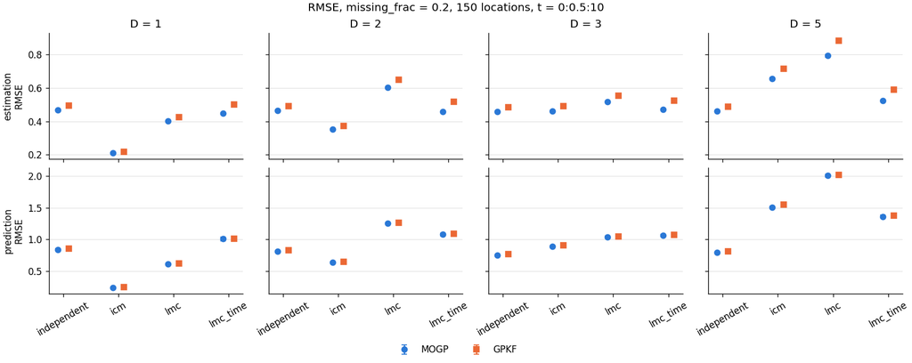

RMSE with 20% missing data.

## Side-by-side figures

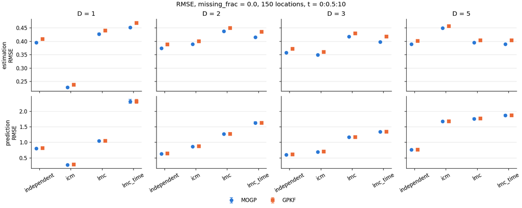

RMSE

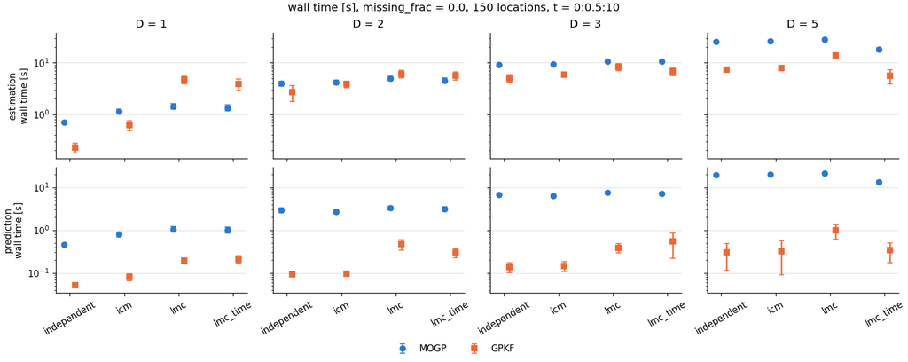

Wall-clock time

## Tabsets

- 0% missing
- 20% missing
- 50% missing

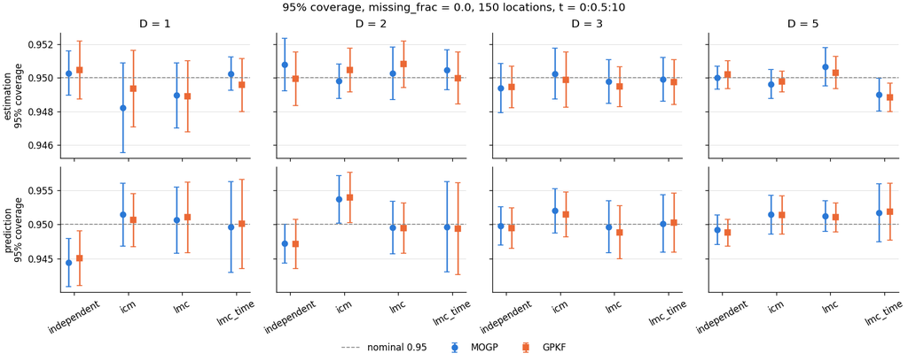

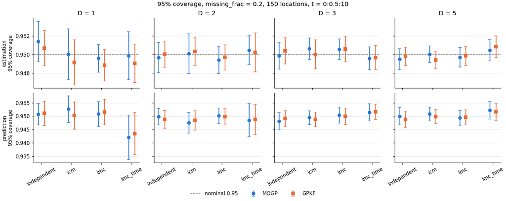

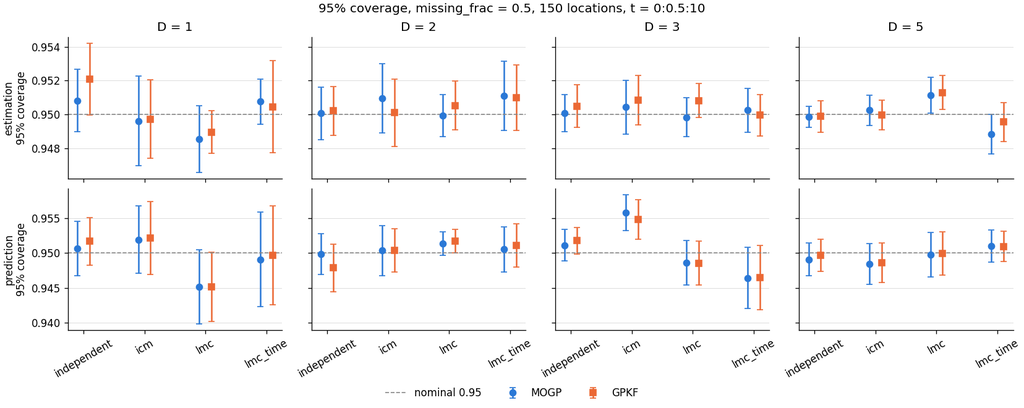

## Table

[output not shown]

# Conclusion

## Thank you!

Questions?

joey.hotz@mail.utoronto.ca

## References

Rasmussen, Carl Edward, and Christopher K. I. Williams. 2006. *Gaussian Processes for Machine Learning*. The MIT Press. https://gaussianprocess.org/gpml/.

Todescato, Marco, Andrea Carron, Ruggero Carli, Gianluigi Pillonetto, and Luca Schenato. 2020. “Efficient spatio-temporal Gaussian regression via Kalman filtering.” *Automatica* 118: 109032. https://doi.org/https://doi.org/10.1016/j.automatica.2020.109032.

# Appendix

## Backup slide

Extra material for questions — not counted in the slide total.